# White Wine Quality por Bruno Henrique Conterato

# Seção de Gráficos Univariados

```
##        X        fixed.acidity    volatile.acidity  citric.acid
##  Min.   :   1   Min.   : 3.800   Min.   :0.0800   Min.   :0.0000
##  1st Qu.:1225   1st Qu.: 6.300   1st Qu.:0.2100   1st Qu.:0.2700
##  Median :2450   Median : 6.800   Median :0.2600   Median :0.3200
##  Mean   :2450   Mean   : 6.855   Mean   :0.2782   Mean   :0.3342
##  3rd Qu.:3674   3rd Qu.: 7.300   3rd Qu.:0.3200   3rd Qu.:0.3900
##  Max.   :4898   Max.   :14.200   Max.   :1.1000   Max.   :1.6600
##  residual.sugar     chlorides       free.sulfur.dioxide
##  Min.   : 0.600   Min.   :0.00900   Min.   :  2.00
##  1st Qu.: 1.700   1st Qu.:0.03600   1st Qu.: 23.00
##  Median : 5.200   Median :0.04300   Median : 34.00
##  Mean   : 6.391   Mean   :0.04577   Mean   : 35.31
##  3rd Qu.: 9.900   3rd Qu.:0.05000   3rd Qu.: 46.00
##  Max.   :65.800   Max.   :0.34600   Max.   :289.00
##  total.sulfur.dioxide    density             pH          sulphates
##  Min.   :  9.0        Min.   :0.9871   Min.   :2.720   Min.   :0.2200
##  1st Qu.:108.0        1st Qu.:0.9917   1st Qu.:3.090   1st Qu.:0.4100
##  Median :134.0        Median :0.9937   Median :3.180   Median :0.4700
##  Mean   :138.4        Mean   :0.9940   Mean   :3.188   Mean   :0.4898
##  3rd Qu.:167.0        3rd Qu.:0.9961   3rd Qu.:3.280   3rd Qu.:0.5500
##  Max.   :440.0        Max.   :1.0390   Max.   :3.820   Max.   :1.0800
##     alcohol         quality
##  Min.   : 8.00   Min.   :3.000
##  1st Qu.: 9.50   1st Qu.:5.000
##  Median :10.40   Median :6.000
##  Mean   :10.51   Mean   :5.878
##  3rd Qu.:11.40   3rd Qu.:6.000
##  Max.   :14.20   Max.   :9.000
```

```
##    Min. 1st Qu.  Median    Mean 3rd Qu.    Max.
##   3.000   5.000   6.000   5.878   6.000   9.000
```

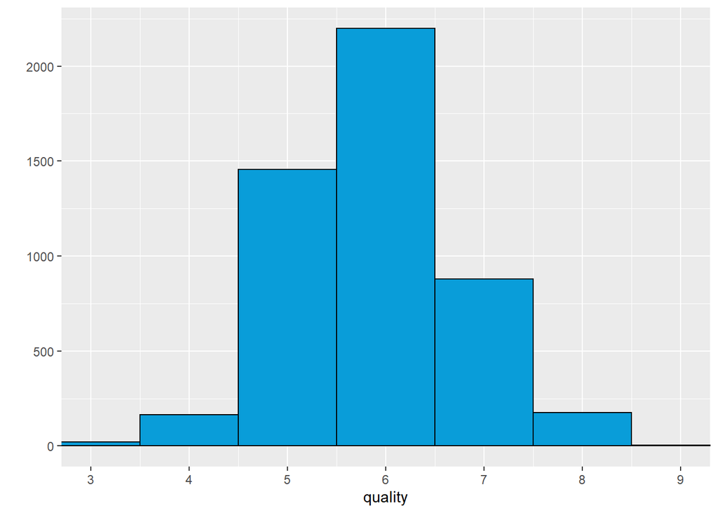

```
##    Min. 1st Qu.  Median    Mean 3rd Qu.    Max.
##   3.800   6.300   6.800   6.855   7.300  14.200
```

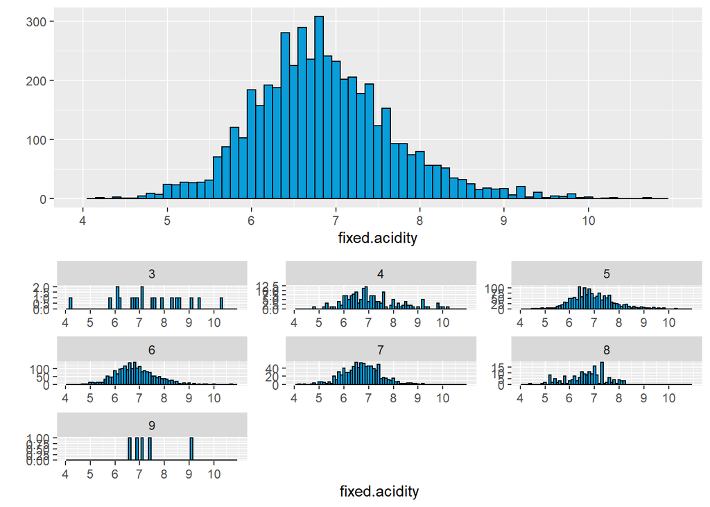

```
##    Min. 1st Qu.  Median    Mean 3rd Qu.    Max.
##  0.0800  0.2100  0.2600  0.2782  0.3200  1.1000
```

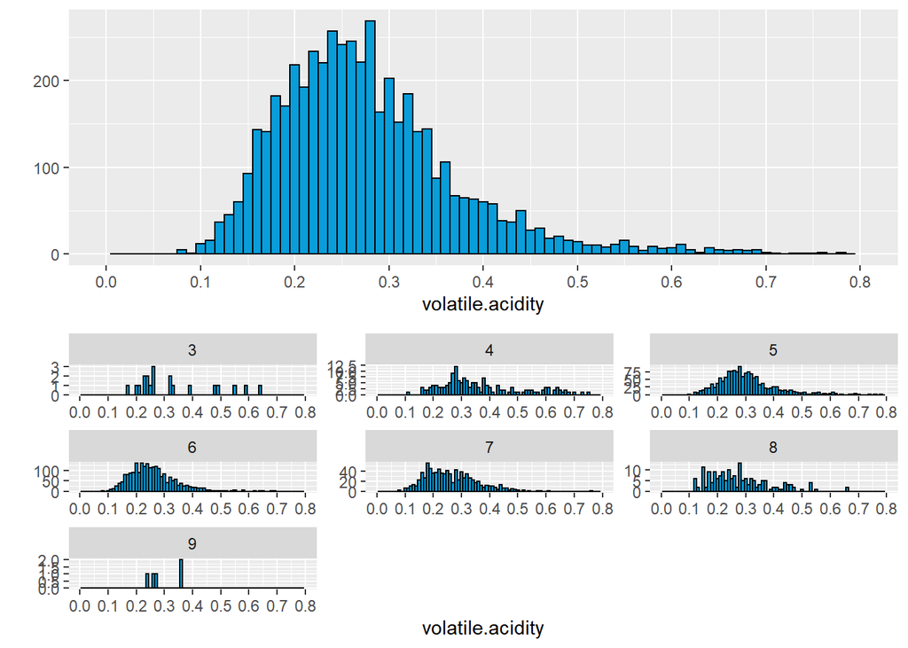

```
##    Min. 1st Qu.  Median    Mean 3rd Qu.    Max.
##  0.0000  0.2700  0.3200  0.3342  0.3900  1.6600
```

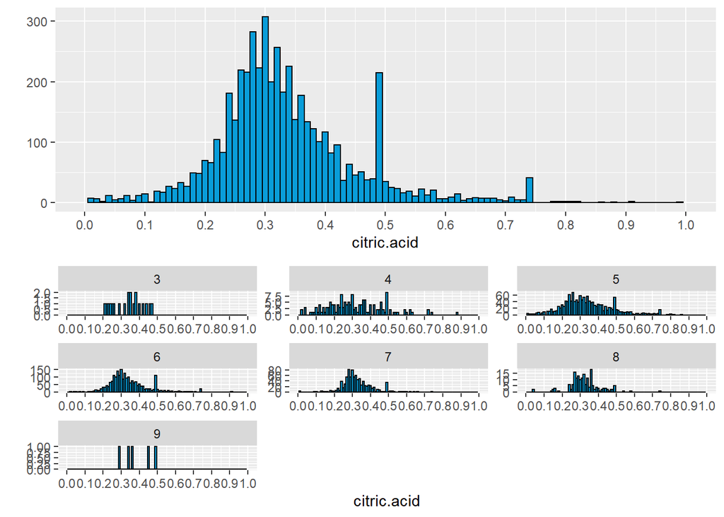

```
##    Min. 1st Qu.  Median    Mean 3rd Qu.    Max.
##   0.600   1.700   5.200   6.391   9.900  65.800
```

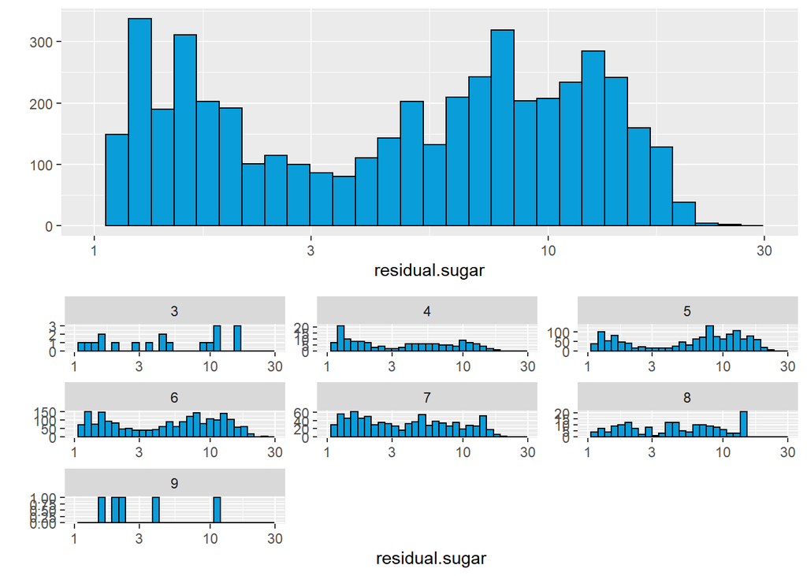

```
##    Min. 1st Qu.  Median    Mean 3rd Qu.    Max.
## 0.00900 0.03600 0.04300 0.04577 0.05000 0.34600
```

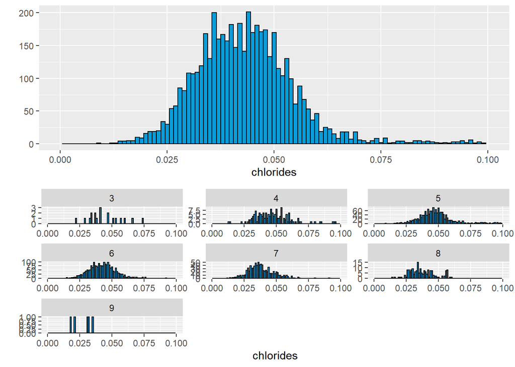

```
##    Min. 1st Qu.  Median    Mean 3rd Qu.    Max.
##    2.00   23.00   34.00   35.31   46.00  289.00
```

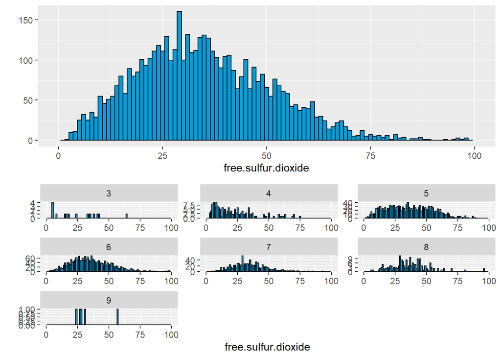

```
##    Min. 1st Qu.  Median    Mean 3rd Qu.    Max.
##     9.0   108.0   134.0   138.4   167.0   440.0
```

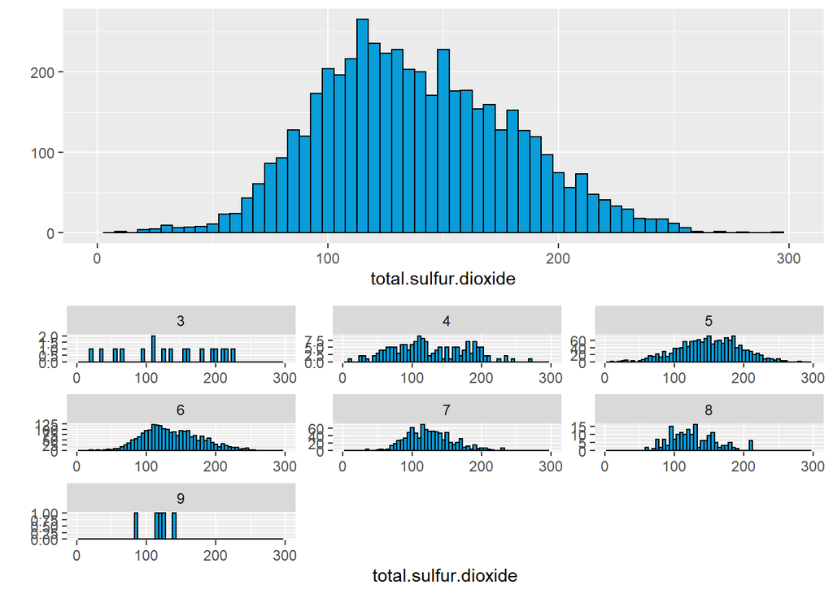

```
##    Min. 1st Qu.  Median    Mean 3rd Qu.    Max.
##  0.9871  0.9917  0.9937  0.9940  0.9961  1.0390
```

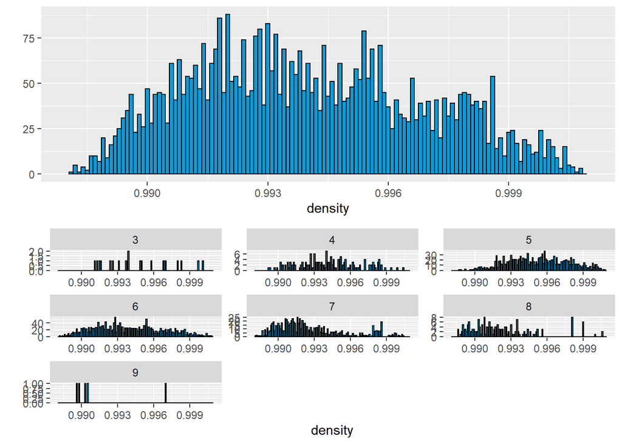

```
##    Min. 1st Qu.  Median    Mean 3rd Qu.    Max.
##   2.720   3.090   3.180   3.188   3.280   3.820
```

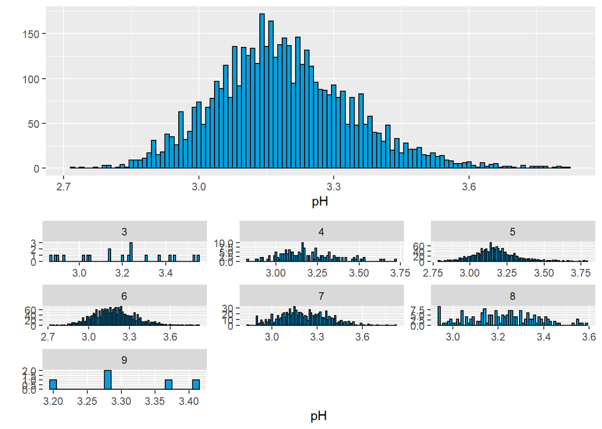

```
##    Min. 1st Qu.  Median    Mean 3rd Qu.    Max.
##  0.2200  0.4100  0.4700  0.4898  0.5500  1.0800
```

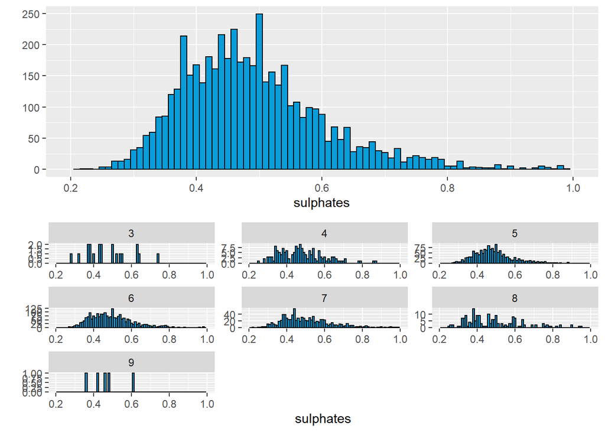

```
##    Min. 1st Qu.  Median    Mean 3rd Qu.    Max.
##    8.00    9.50   10.40   10.51   11.40   14.20
```

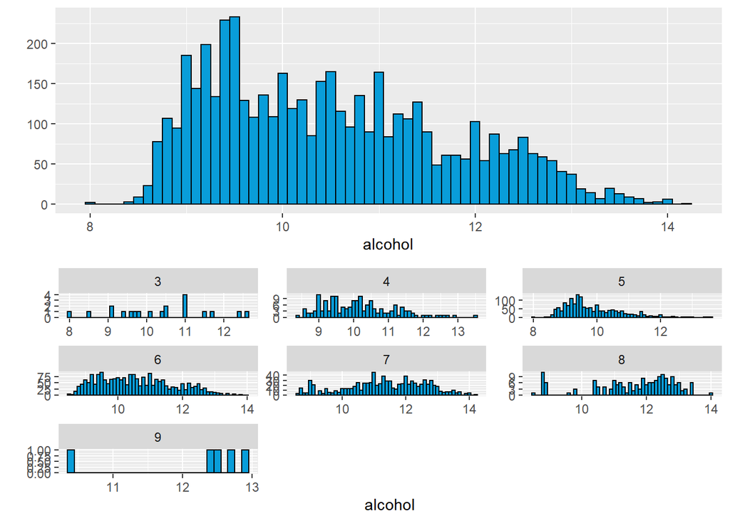

# Análise Univariada

### Qual é a estrutura do conjunto de dados?

Nosso conjunto de dados tem 13 variáveis em 4898 observações. Como se vê:

```r
str(wineData)
```

```
## 'data.frame':    4898 obs. of  13 variables:
##  $ X                   : int  1 2 3 4 5 6 7 8 9 10 ...
##  $ fixed.acidity       : num  7 6.3 8.1 7.2 7.2 8.1 6.2 7 6.3 8.1 ...
##  $ volatile.acidity    : num  0.27 0.3 0.28 0.23 0.23 0.28 0.32 0.27 0.3 0.22 ...
##  $ citric.acid         : num  0.36 0.34 0.4 0.32 0.32 0.4 0.16 0.36 0.34 0.43 ...
##  $ residual.sugar      : num  20.7 1.6 6.9 8.5 8.5 6.9 7 20.7 1.6 1.5 ...
##  $ chlorides           : num  0.045 0.049 0.05 0.058 0.058 0.05 0.045 0.045 0.049 0.044 ...
##  $ free.sulfur.dioxide : num  45 14 30 47 47 30 30 45 14 28 ...
##  $ total.sulfur.dioxide: num  170 132 97 186 186 97 136 170 132 129 ...
##  $ density             : num  1.001 0.994 0.995 0.996 0.996 ...
##  $ pH                  : num  3 3.3 3.26 3.19 3.19 3.26 3.18 3 3.3 3.22 ...
##  $ sulphates           : num  0.45 0.49 0.44 0.4 0.4 0.44 0.47 0.45 0.49 0.45 ...
##  $ alcohol             : num  8.8 9.5 10.1 9.9 9.9 10.1 9.6 8.8 9.5 11 ...
##  $ quality             : int  6 6 6 6 6 6 6 6 6 6 ...
```

Todas as variáveis são números reais, exceto X (o índice do vinho, variando de 1 a 4898) e A qualidade do vinho atestada pelos especialistas (na amostra vaira de 3 a 9). Essas variáveis representam algumas concentrações químicas de determinadas substâncias além do pH e do teor alcóolico.

### Quais são os principais atributos de interesse deste conjunto de dados?

Os principais atributos são o índice X — identificando o próprio vinho que está em análise — e a qualidade — atributo mais determinante para o valor comercial e a popularidade do vinho, talvez o único fator relevante para a maioria dos consumidores (leigos).

### Quais outros atributos você acha que podem lhe auxiliar na investigação destes atributos de interesse?

Os atributos do conjunto de dados:

```r
names(wineData)
```

```
##  [1] "X"                    "fixed.acidity"        "volatile.acidity"
##  [4] "citric.acid"          "residual.sugar"       "chlorides"
##  [7] "free.sulfur.dioxide"  "total.sulfur.dioxide" "density"
## [10] "pH"                   "sulphates"            "alcohol"
## [13] "quality"
```

Acredito que os mais importantes para determinar a qualidade do vinho — analisando os face_wraps — sejam pH, alcool, densidade e ácido cítrico (já que percebe-se maior diferença entre esses os gráficos com relação à qualidade). Talvez possamos fazer um modelo preditivo baseado nesses 3 fatores e 1 ou 2 outros fatores adicionais.

### Você criou novas variáveis a partir dos atributos existentes no conjunto de dados?

Novas variáveis não foram criadas.

### Dos atributos investigados, distribuições incomuns foram encontradas? Você aplicou operações nos dados para limpá-los, ajustá-los ou mudar a forma dos dados? Se sim, por quê?

Apliquei operação de transformação logarítimica no açúcar residual, porque o gráfico mostrou distribuição exponencial negativa nessa variável.

Além disso, quase todos os gráficos (exceto qualidade, ph e álcool) tiveram valores extremos extraídos do alcance do gráfico, a fim de concentrar a análise na porção mais central da amostra para todas as características, e melhorar a visualização dos dados centrais:

# Seção de Gráficos Bivariados

Vamos olhar a matrix scatter procurando por correlações nos dados

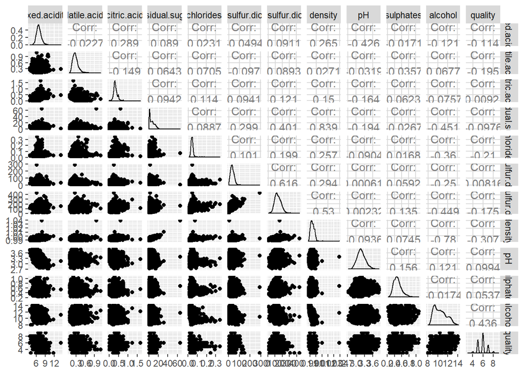

Primeiramente, vamos analisar a relação entre açúcar residual e densidade, tida como a mais forte correlação dos nossos dados:

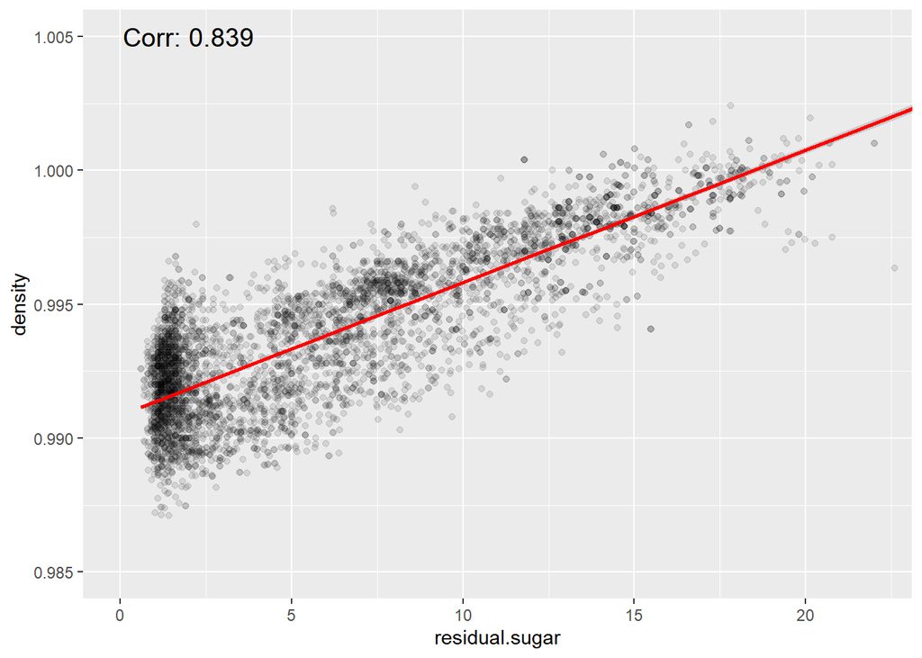

Podemos verificar graficamente a correlação entre açúcar residual e densidade.

Vamos também verificar a correlação entre densidade e álcool:

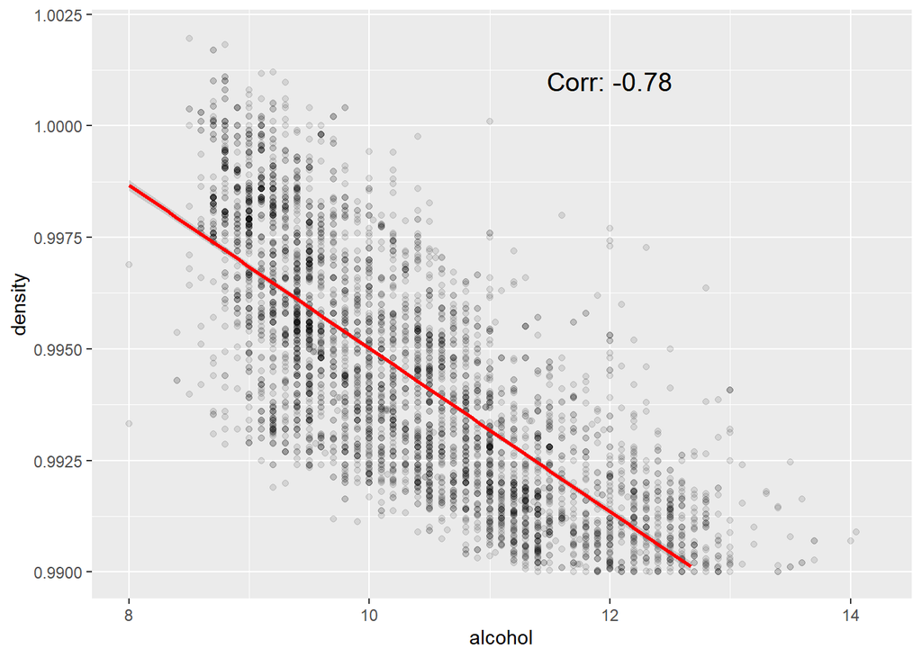

Nota-se a correlação negativa entre densidade e álcool.

Vamos especialmente trabalhar a esperada relação entre álcool e qualidade:

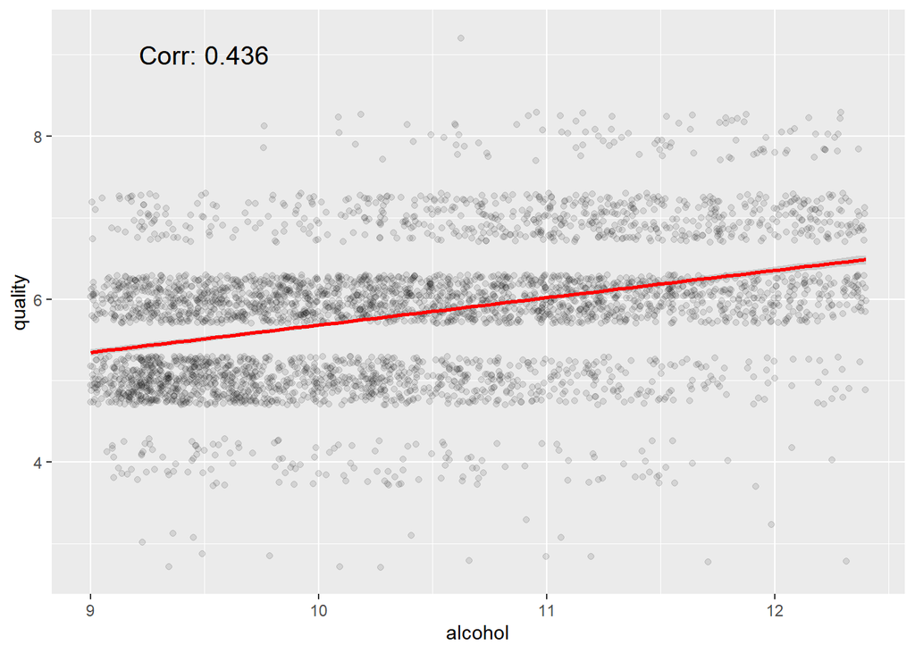

No gráfico acima, podemos observar pela coloração mais escura que existe uma correlação entre maioers quantidades de álcool e maior qualidade.

Vamos analisar o boxplot:

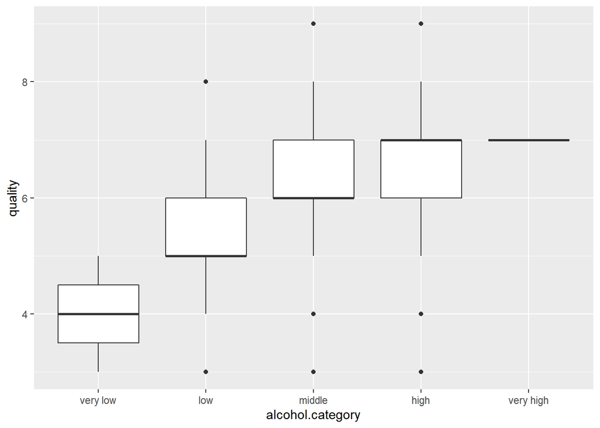

```
## wineData$alcohol.category: very low
##    Min. 1st Qu.  Median    Mean 3rd Qu.    Max.
##     3.0     3.5     4.0     4.0     4.5     5.0
## --------------------------------------------------------
## wineData$alcohol.category: low
##    Min. 1st Qu.  Median    Mean 3rd Qu.    Max.
##   3.000   5.000   5.000   5.516   6.000   8.000
## --------------------------------------------------------
## wineData$alcohol.category: middle
##    Min. 1st Qu.  Median    Mean 3rd Qu.    Max.
##   3.000   6.000   6.000   5.996   7.000   9.000
## --------------------------------------------------------
## wineData$alcohol.category: high
##    Min. 1st Qu.  Median    Mean 3rd Qu.    Max.
##   3.000   6.000   7.000   6.592   7.000   9.000
## --------------------------------------------------------
## wineData$alcohol.category: very high
##    Min. 1st Qu.  Median    Mean 3rd Qu.    Max.
##       7       7       7       7       7       7
```

Podemos observar que quantidades maiores de alcool costumam implicar mais qualidade.

Vamos fazer o mesmo entre densidade e qualidade:

```
## wineData$density.category: very low
##    Min. 1st Qu.  Median    Mean 3rd Qu.    Max.
##   4.000   6.000   7.000   6.582   7.000   9.000
## --------------------------------------------------------
## wineData$density.category: low
##    Min. 1st Qu.  Median    Mean 3rd Qu.    Max.
##   3.000   6.000   6.000   6.117   7.000   9.000
## --------------------------------------------------------
## wineData$density.category: middle
##    Min. 1st Qu.  Median    Mean 3rd Qu.    Max.
##   3.000   5.000   6.000   5.687   6.000   8.000
## --------------------------------------------------------
## wineData$density.category: high
##    Min. 1st Qu.  Median    Mean 3rd Qu.    Max.
##   3.000   5.000   6.000   5.601   6.000   9.000
## --------------------------------------------------------
## wineData$density.category: very high
##    Min. 1st Qu.  Median    Mean 3rd Qu.    Max.
##    3.00    5.00    5.00    5.58    6.00    8.00
```

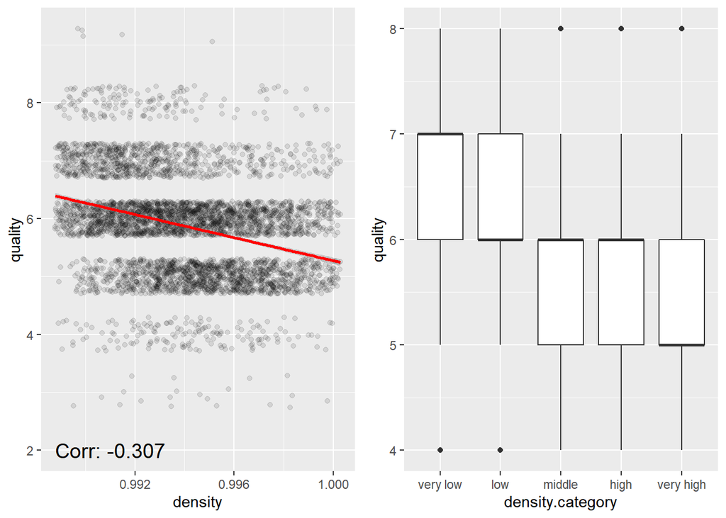

# Análise Bivariada

### Discuta sobre alguns dos relacionamentos observados nesta parte da investigação. Como os atributos de interesse variaram no conjunto de dados?

Vamos discutir as seguintes relações:

1. As duas correlaçoes mais fortes:
- Açúcar residual e densidade (0.839)
- Densidade e álcool (-0.78)
2. As duas correlaçoes mais importantes para a qualidade do vinho:
- Álcool e qualidade (0.436)
- Densidade e qualidade (-0.307)

1.1. Açúcar residual x densidade Nota-se uma correlação positiva de 0.839. Dado que densidade = massa / volume, a quantidade mais elevada de açúcar pode ter efeito de aumentar a massa do vinho proporcionalmente mais do que aumenta o volume, provocando uma tendência de aumentar a densidade.

1.2. Densidade x álcool Nota-se correlação negativa de magnitude 0.78. Razoável, haja vista a densidade do álcool (789 kg/m³) ser menor que a da água (997 kg/m³), valores extraídos da wikipedia em 13/08/2019. Valores mais elevados de álcool portanto devem influenciar negativamente na densidade.

2.1. Álcool x qualidade Nota-se uma correlação positiva de 0.436. Dividindo os vinhos em categorias quanto ä quantidade de álcool, e plotando o gráfico de dispersão, notamos que quanto mais álcool, maior tende a ser a qualidade percebida do vinho.

2.2 Densidade e qualidade Nota-se uma correlação negativa de magnitude 0.307. Pelo gráfico de dispersão perceboms a relação decrescente entre aumento de densidade e redução da qualidade.

Obs.: Juntando-se as relações 1.2, 2.1 e 2.2, pode-se observar que talvez um dos fatores — alcool e densidade — tenham grande influência um no outro, e portanto não tenha influência significativa na qualidade do vinho! Por se tratar de uma bebida alcóolica, e também pela diferença de densidade entre água e álcool, eu arriscaria o palpite de que o álcool influencia mais a qualidade do produto do que a densidade, já que a densidade sofre grande influência da quantidade de álcool.

### Qual foi o relacionamento mais forte encontrado?

O relacionamento mais forte encontrado foi entre Açúcar residual e densidade, discutido acima.

# Seção de Gráficos Multivariados

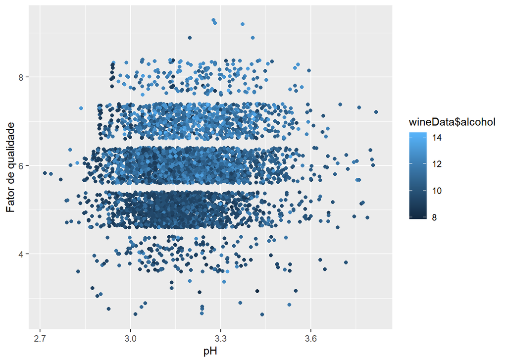

Esse gráfico nos mostra que há uma relação entre a qualidade, o pH e à quantidade de álcool Qualidades superiores geralmente são alcançadas com mais álcool, pH um pouco maior. A maior presença de pontos azuis claros na parte de cima são evidência da relaçao entre álcool e qualiadde. Além disso, os pontos azuis claros estão um pouco mais ao centro quando se olha na horizontal, evidenciando essa região (pH entre 3.1 e 3.3) como sendo maisdeterminante. A relação, contudo, é fraca.

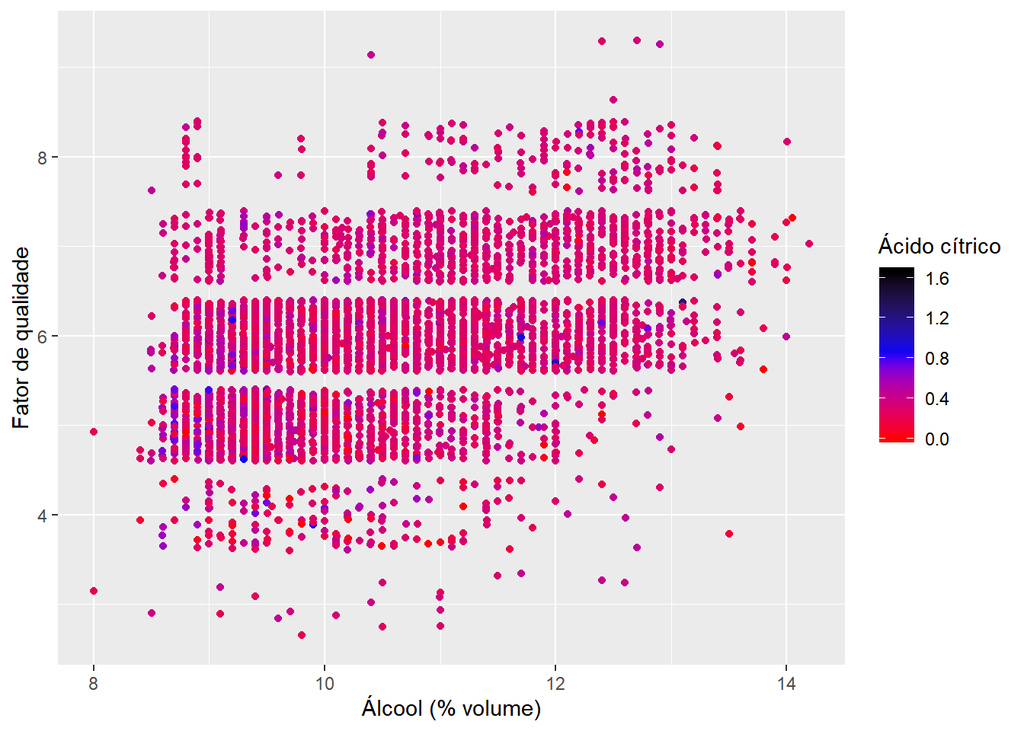

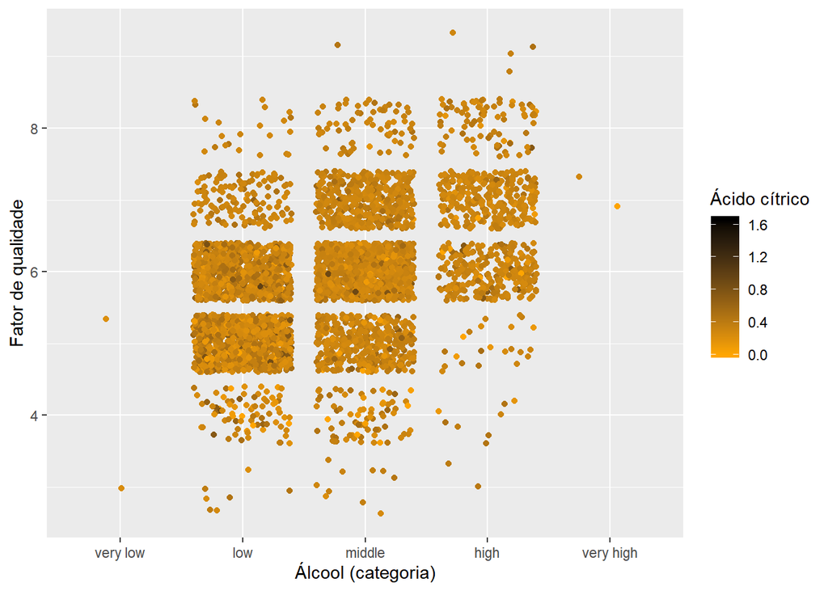

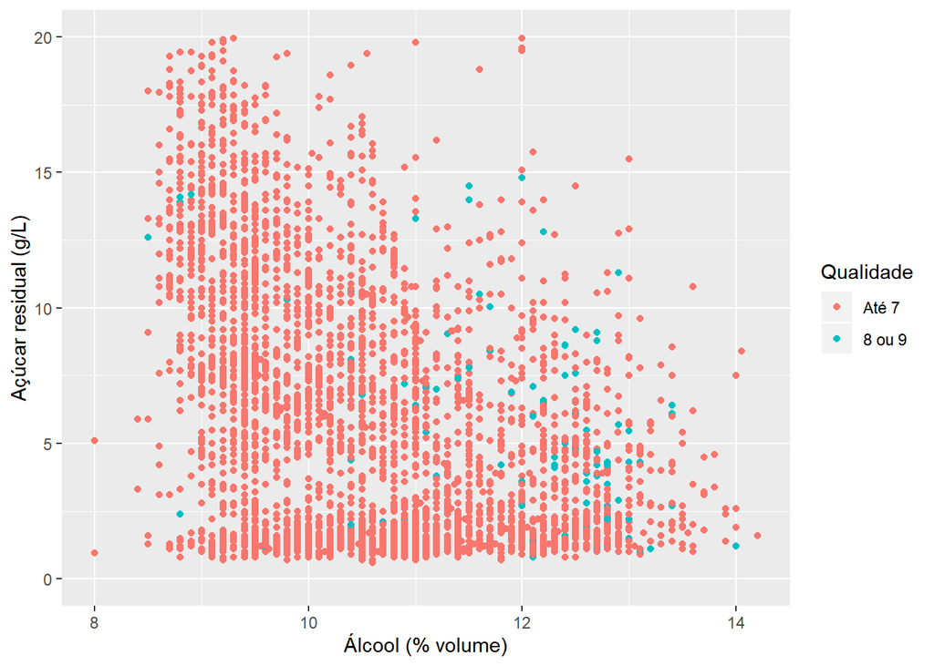

Comprova-se acima novamente a influência de mais álcool, pouca influência do açúcar residual.

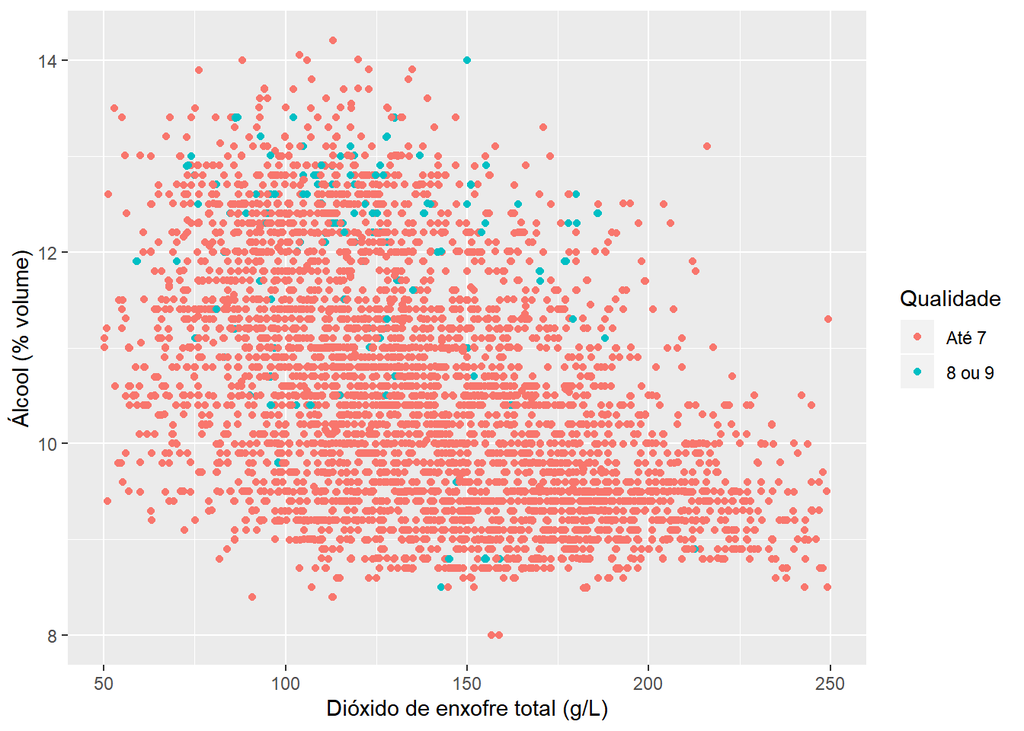

# Análise Multivariada

### Discuta sobre os relacionamentos observados nesta parte da investigação. Quais atributos que fortaleceram os demais na observação das variáveis de interesse?

Nesta parte da investigação, mantivemos a hipótese de que o álcool é um dos principais fatores responsáveis pela qualidade. O pH também tem influência, porem menos que o álcool. Outros fatores (como o ácido cítrico) geralmente pouco influenciam quando analisados em conjunto.

### Interações surpreendentes e/ou interessantes foram encontradas entre os atributos?

Aparentemente alguns dos atributos parecem não ter grande influência na qualidade. O ácido cítrico, por exemplo, mostrado nos gráficos acima, não mostra grande influência nem combinado com quantidade maior de álcool.

### OPCIONAL: Modelos foram criados usando este conjunto de dados? Discuta sobre os pontos fortes e as limitações do seu modelo.

# Gráficos Finais e Sumário

### Primeiro Gráfico

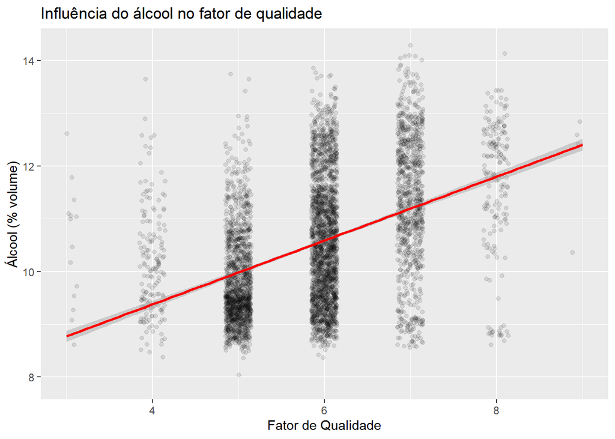

### Descrição do Primeiro Gráfico

Relação de correlação positivamente orientada entre álcool e a qualidade do vinho. O álcool provou ser o fator com mais influência na determinação da qualidade do Vinho. Note que mais álcool se correlaciona a vinhos melhores.

### Segundo Gráfico

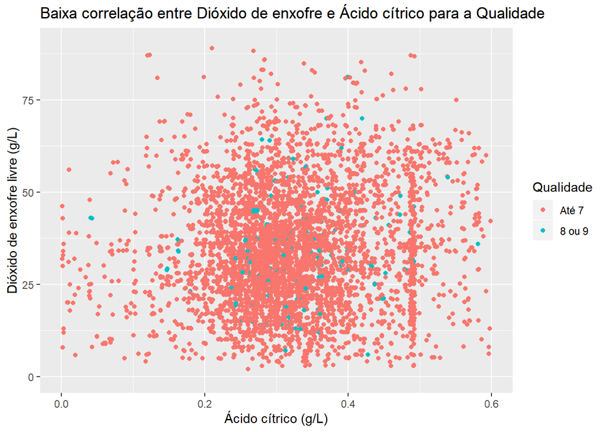

### Descrição do Segundo Gráfico

Gráfico mostrando a baixa correlação entre ácido cítrico e dióxido de enxofre livre para a determinação da qualidade. Note a quantidade de pontos azuis claros distribuídos de forma aparentemente caótica pelo gráfico.

### Terceiro Gráfico

```
## No summary function supplied, defaulting to `mean_se()
```

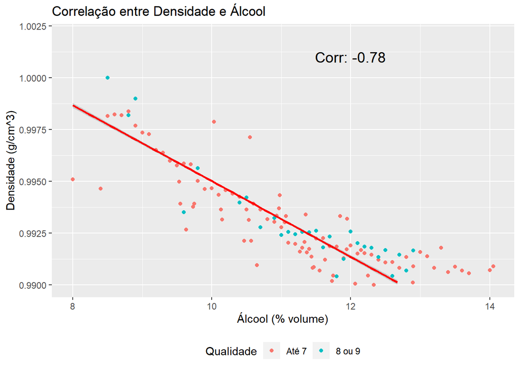

### Descrição do Terceiro Gráfico

## Correlação negativa entre densidade e alcohol (já esperada, conforme discutimos na análise bivariada). Evidenciamos também maior concentração de pontos azuis (vinhos melhores) em mais baixas densidades e maiores volumes alcoólicos.

# Reflexão

Durante a exploração dos dados, foi bastante rápido e evidente que o álcool se tratava do fator mais importante para determinação da qualidade. Já no histograma dividido pela qualidade (gráficos univariados) foi possível notar que a distribuição parece deslocar para a direita na medida em que passamos a analisar maior qualidade, indicando uma correlação positiva. A análise bivariada confirmou essa relação, enquanto a matriz de dispersão provou que realmente era a maior das correlações.

Com excessão do álcool e da densidade, foi difícil procurar por outras relações. Tentei vários gráficos procurando influência forte de outros fatores (alguns estão na seção de gráficos multivariados), mas a distribuição de vinhos pela qualidade parecia caótica. Concluí, portanto, que realmente a maioria desses fatores tem relevãncia baixa.

# Algumas referências

https://www.rdocumentation.org/packages/GGally/versions/1.4.0/topics/ggpairs

http://environmentalcomputing.net/plotting-with-ggplot-colours-and-symbols/

https://ggobi.github.io/ggally/rd.html#gglegend

https://stackoverflow.com/questions/47969912/generalised-matrix-scatterplots-in-ggplot2

Other Stackoverflow questions

http://sape.inf.usi.ch/quick-reference/ggplot2/colour

https://www.datanovia.com/en/blog/ggplot-colors-best-tricks-you-will-love/

https://ggplot2.tidyverse.org/reference/scale_gradient.html

http://www.cookbook-r.com/Graphs/Colors_(ggplot2)/

https://www.datanovia.com/en/blog/ggplot-title-subtitle-and-caption/